# DataPreprocessing

```python
%matplotlib inline
import pandas as pd
import numpy as np
import re, string
from tensorflow.keras.layers import  Dropout, Dense
from tensorflow.keras.models import Sequential
from sklearn.feature_extraction.text import TfidfVectorizer
from sklearn import metrics
```

### Read the dataset

```python
pt1= pd.read_excel('../groups.xlsx',sheet_name='Sheet1')
# pt1.drop_duplicates(subset ="Name",
#                      keep = False, inplace = True)
```

```python
pt1["What we're about"].head()
```

```
0    Comedy show wrapped in a 70’s style burrito. D...
1    Interested in Experiencing local art in Deep E...
2    Meet with other local people who enjoy the per...
3    This is a group for anyone interested in drawi...
4    This group is brought to you by VERB KULTURE E...
Name: What we're about, dtype: object
```

### Split unique words from the description of each group. (field: What we're about)

#### Remove Punctuation

```python
def clean_text(article):
    clean1 = re.sub(r'['+string.punctuation + '’—”'+']', "", article.lower())
    return re.sub(r'\W+', ' ', clean1)
```

#### Remove Digits

```python
from string import digits
remove_digits = str.maketrans('', '', digits)
pt1['tokenized'] = pt1["What we're about"].map(lambda x: clean_text(str(x).translate(remove_digits)))
```

```python
pt1['tokenized'].head()
```

```
0    comedy show wrapped in a s style burrito dj sp...
1    interested in experiencing local art in deep e...
2    meet with other local people who enjoy the per...
3    this is a group for anyone interested in drawi...
4    this group is brought to you by verb kulture e...
Name: tokenized, dtype: object
```

### Lemmatization

Lemmatisation (or lemmatization) in linguistics is the process of grouping together the inflected forms of a word so they can be analysed as a single item, identified by the word's lemma, or dictionary form.

In computational linguistics, lemmatisation is the algorithmic process of determining the lemma of a word based on its intended meaning. Unlike stemming, lemmatisation depends on correctly identifying the intended part of speech and meaning of a word in a sentence, as well as within the larger context surrounding that sentence, such as neighboring sentences or even an entire document. As a result, developing efficient lemmatisation algorithms is an open area of research.

```python
from nltk.stem import WordNetLemmatizer
from nltk.tokenize import word_tokenize
lemma_word = []
wordnet_lemmatizer = WordNetLemmatizer()
for i, row in pt1.iterrows():
    word = ""
    for w in row['tokenized'].split():
        word1 = wordnet_lemmatizer.lemmatize(w, pos = "n")
        word2 = wordnet_lemmatizer.lemmatize(word1, pos = "v")
        word3 = wordnet_lemmatizer.lemmatize(word2, pos = ("a"))
        word  = word + " " + word3
    lemma_word.append(word)
```

```python
pt1['lemma_word'] = lemma_word
pt1['lemma_word'].head()
```

```
0     comedy show wrap in a s style burrito dj spin...
1     interest in experience local art in deep ellu...
2     meet with other local people who enjoy the pe...
3     this be a group for anyone interest in draw o...
4     this group be bring to you by verb kulture en...
Name: lemma_word, dtype: object
```

```python
from nltk.corpus import stopwords
X = []
for i, row in pt1.iterrows():
    for sw in stopwords.words('english'):
        words = str(row['lemma_word']).replace(sw,"")
    X.append(words)
pt1['corpus'] = X
```

### Overview the distribution of this dataset

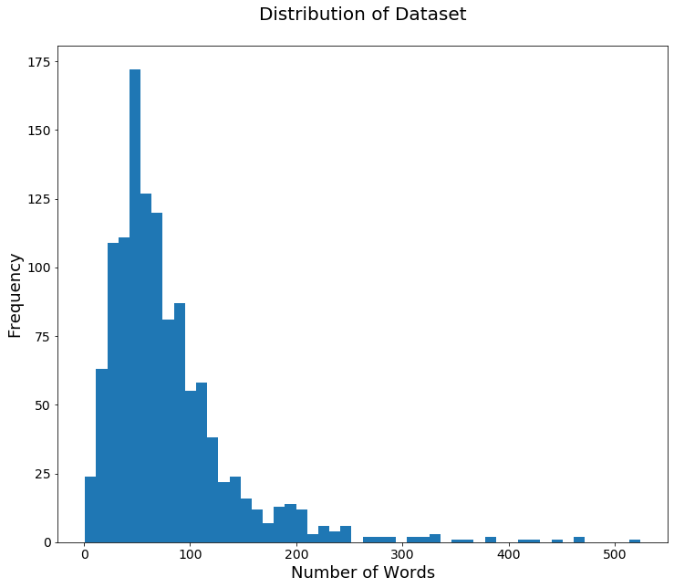

```python
pt1['num_wds'] = pt1['corpus'].str.split().apply(lambda x: len(set(x)))
ax=pt1['num_wds'].plot(kind='hist', bins=50, fontsize=14, figsize=(12,10))
ax.set_title('Distribution of Dataset\n', fontsize=20)
ax.set_ylabel('Frequency', fontsize=18)
ax.set_xlabel('Number of Words', fontsize=18);
```

```python
pt1 = pt1[pt1['num_wds']>=10]
```

### Convert text to Text Array (Bag of words)

```python
from collections import Counter
wd_counts = Counter()
for i, row in pt1.iterrows():
    wd_counts.update(row['corpus'].split())
```

#### To see the top 30 frequency words.

```python
wd_counts.most_common(30)
```

```
[('and', 6373),
 ('to', 5886),
 ('be', 5616),
 ('the', 5393),
 ('a', 4383),
 ('of', 3409),
 ('in', 2614),
 ('you', 2390),
 ('for', 2358),
 ('we', 2170),
 ('group', 1725),
 ('our', 1439),
 ('this', 1391),
 ('with', 1345),
 ('or', 1304),
 ('your', 1059),
 ('that', 1056),
 ('have', 1053),
 ('on', 991),
 ('will', 934),
 ('at', 836),
 ('meet', 825),
 ('event', 825),
 ('all', 822),
 ('who', 747),
 ('it', 732),
 ('if', 726),
 ('dallas', 646),
 ('u', 599),
 ('join', 591)]
```

#### To see how many unique words we have

```python
len(set(wd_counts))
```

```
10332
```

### TF-IDF

In information retrieval, tf–idf or TFIDF, short for term frequency–inverse document frequency, is a numerical statistic that is intended to reflect how important a word is to a document in a collection or corpus.It is often used as a weighting factor in searches of information retrieval, text mining, and user modeling. The tf–idf value increases proportionally to the number of times a word appears in the document and is offset by the number of documents in the corpus that contain the word, which helps to adjust for the fact that some words appear more frequently in general. tf–idf is one of the most popular term-weighting schemes today; 83% of text-based recommender systems in digital libraries use tf–idf.

```python
pt1 = pt1.reset_index()
vectorizer = TfidfVectorizer()
vectors = vectorizer.fit_transform(pt1['corpus'])
feature_names = vectorizer.get_feature_names()
dense = vectors.todense()
denselist = dense.tolist()
df = pd.DataFrame(denselist, columns=feature_names)
```

```python
df.head()
```

|  | aarp | ab | abandon | abandonded | abatement | abc | aberg | abide | abilene | ability | ... | 𝔸𝕡𝕣𝕚𝕝 | 𝔼𝕤𝕥 | 𝘾𝙤𝙢𝙢𝙪𝙣𝙞𝙩𝙮 | 𝙂𝙑𝙊 | 𝙂𝙤𝙤𝙙 | 𝙂𝙤𝙤𝙙𝙑𝙞𝙗𝙚𝙨𝙊𝙣𝙡𝙮 | 𝙊𝙣𝙡𝙮 | 𝙑𝙞𝙗𝙚𝙨 | 𝟚𝟘 | 𝟚𝟘𝟙𝟡 |
| --- | --- | --- | --- | --- | --- | --- | --- | --- | --- | --- | --- | --- | --- | --- | --- | --- | --- | --- | --- | --- | --- |
| 0 | 0.0 | 0.0 | 0.0 | 0.0 | 0.0 | 0.0 | 0.0 | 0.0 | 0.0 | 0.0 | ... | 0.0 | 0.0 | 0.0 | 0.0 | 0.0 | 0.0 | 0.0 | 0.0 | 0.0 | 0.0 |
| 1 | 0.0 | 0.0 | 0.0 | 0.0 | 0.0 | 0.0 | 0.0 | 0.0 | 0.0 | 0.0 | ... | 0.0 | 0.0 | 0.0 | 0.0 | 0.0 | 0.0 | 0.0 | 0.0 | 0.0 | 0.0 |
| 2 | 0.0 | 0.0 | 0.0 | 0.0 | 0.0 | 0.0 | 0.0 | 0.0 | 0.0 | 0.0 | ... | 0.0 | 0.0 | 0.0 | 0.0 | 0.0 | 0.0 | 0.0 | 0.0 | 0.0 | 0.0 |
| 3 | 0.0 | 0.0 | 0.0 | 0.0 | 0.0 | 0.0 | 0.0 | 0.0 | 0.0 | 0.0 | ... | 0.0 | 0.0 | 0.0 | 0.0 | 0.0 | 0.0 | 0.0 | 0.0 | 0.0 | 0.0 |
| 4 | 0.0 | 0.0 | 0.0 | 0.0 | 0.0 | 0.0 | 0.0 | 0.0 | 0.0 | 0.0 | ... | 0.0 | 0.0 | 0.0 | 0.0 | 0.0 | 0.0 | 0.0 | 0.0 | 0.0 | 0.0 |

5 rows × 10305 columns

```python
all_tfidf = pd.DataFrame(df.mean())
all_tfidf.columns = ["Score"]
all_tfidf = all_tfidf.sort_values(by=['Score'],ascending=False)
```

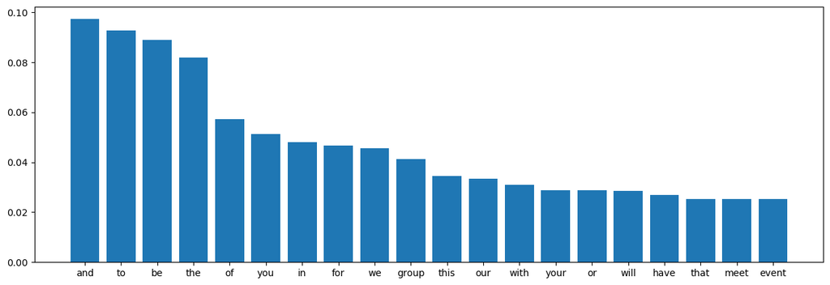

```python
import matplotlib.pyplot as plt
fig=plt.figure(figsize=(15, 5), dpi= 100, facecolor='w', edgecolor='k')
names = all_tfidf.index.values[0:20]
plt.bar(range(20),list(all_tfidf.iloc[0:20]['Score']),tick_label=names)
plt.show()
```

#### Normal frequency count table

```python
wordDict1 = dict.fromkeys(wd_counts,0)
print(len(set(wordDict1)))
data=[]
for i,row in pt1.iterrows():
    wordDict = wordDict1.copy()
    rowSet = set(row['corpus'].split())
    for word in rowSet:
        try:
            wordDict[word] +=1
        except:
            continue
    data.append(wordDict)
df1 = pd.DataFrame(data)
df1.head()
```

```
10332
```

|  | comedy | show | wrap | in | a | s | style | burrito | dj | spinnin | ... | subconscious | itsonia | strategize | httpwwwwritethedocsorg | wtd | portland | berlin | documentarians | httpwwwwritethedocsorgslack | httpwwwwritethedocsorgcodeofconduct |
| --- | --- | --- | --- | --- | --- | --- | --- | --- | --- | --- | --- | --- | --- | --- | --- | --- | --- | --- | --- | --- | --- |
| 0 | 1 | 1 | 1 | 1 | 1 | 1 | 1 | 1 | 1 | 1 | ... | 0 | 0 | 0 | 0 | 0 | 0 | 0 | 0 | 0 | 0 |
| 1 | 0 | 0 | 0 | 1 | 0 | 0 | 0 | 0 | 1 | 0 | ... | 0 | 0 | 0 | 0 | 0 | 0 | 0 | 0 | 0 | 0 |
| 2 | 0 | 1 | 0 | 0 | 1 | 0 | 0 | 0 | 0 | 0 | ... | 0 | 0 | 0 | 0 | 0 | 0 | 0 | 0 | 0 | 0 |
| 3 | 0 | 0 | 0 | 1 | 1 | 0 | 0 | 0 | 0 | 0 | ... | 0 | 0 | 0 | 0 | 0 | 0 | 0 | 0 | 0 | 0 |
| 4 | 0 | 0 | 0 | 0 | 1 | 0 | 0 | 0 | 0 | 0 | ... | 0 | 0 | 0 | 0 | 0 | 0 | 0 | 0 | 0 | 0 |

5 rows × 10332 columns

#### Using WordCloud to see the distribution of words

```python
from wordcloud import WordCloud
word_freq1 = all_tfidf.iloc[0:201].T.to_dict('index')
word_freq = word_freq1['Score']
```

```
(-0.5, 999.5, 999.5, -0.5)
```

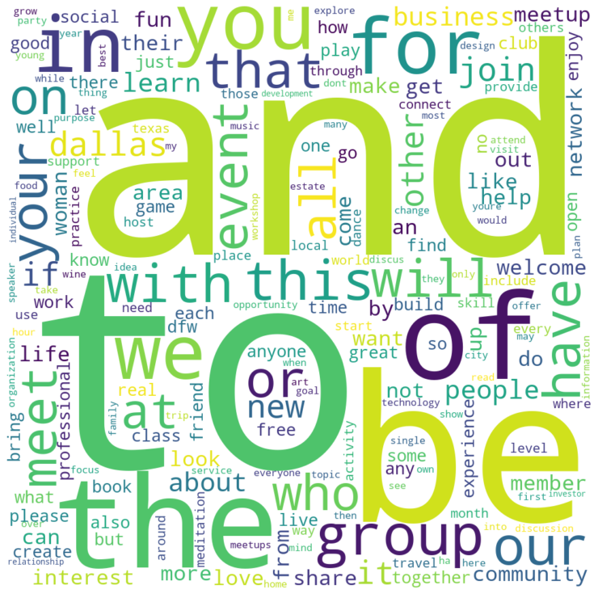

```python
fig=plt.figure(figsize=(14, 12), dpi= 80, facecolor='w', edgecolor='k')
wc = WordCloud(background_color="white",width=1000,height=1000, max_words=300,relative_scaling=0.25,normalize_plurals=True).generate_from_frequencies(word_freq)
plt.imshow(wc, interpolation='bilinear')
plt.axis("off")
```

#### Randomly select 60% data as the training sample, the rest as the testing sample

```python
df['Category'] = pt1['Category']
df1['Category'] = pt1['Category']
df_train=df.sample(frac=0.60,random_state=1207)
df_test=df.drop(df_train.index)
df_train1=df1.sample(frac=0.60,random_state=1207)
df_test1=df1.drop(df_train.index)
```

#### Save the training and testing dataset

```python
df_train1.to_excel("Training.xlsx", encoding='utf-8')
df_test1.to_excel("Testing.xlsx", encoding='utf-8')
df_train.to_excel("TFIDFTraining.xlsx", encoding='utf-8')
df_test.to_excel("TFIDFTesting.xlsx", encoding='utf-8')
```